# 4.2 - Linear Models

Prediction, Linear Models, and R<sup>2</sup>

### Predicting Variables : The Linear Model

In this lecture, we’ll first **recap** the main idea of prediction. Next, we’ll **define** the linear model, and explain the theory behind how it’s used to make predictions. We’ll then **demonstrate** how to build a model using R (it is easy!) and interpret that model using our brains. Finally, you’ll get to **use R** to apply these skills and create your very own model.

*Note*: if you want to follow along with these analyses, you will need to first install the car package by running `install.packages('car')` in your R console. You will only need to run this command ONCE, but will need to run `library(car)` each time you restart Rstudio and want to work with this package.

#### Recap (Prediction)

Our goal is to make predictions about people, while recognizing that our predictions will not perfectly match what actually happens (which we call error).

Conceptually, we can think of a person’s actual score on $y$ (some variable) as the sum of our prediction and the error in our prediction (with the goal to minimize error as much as possible). As an equation, we would write this as:

$$actual.score = our.prediction + error$$

Great! But the real question is WHAT should define our prediction?

Last lecture, we learned how *the mean* was a simple way to make a prediction about individuals. Let’s review this idea, and set up the linear model, by working with a classic dataset in teaching statistic - the Prestige dataset. These data are contained in the `car` package, and are used in one of the classic R textbooks - John Fox’ *Applied Regression Analysis and Generalized Linear Models (2nd Edition)*. To be honest, it’s not the most thrilling dataset, but will be good for learning. Like learning to drive in a parking lot before jumping on the 580 to the 5 on your way to LA.

```r
library(car) # loading the library - make sure you installed it first!
presto <- Prestige # creating a copy of the dataset
names(presto)
```

```
## [1] "education" "income"    "women"     "prestige"  "census"    "type"
```

You can read more about these variables by typing in `?Prestige` to access the help page for the dataset.

For this lecture, we’ll be working with the variable `prestige`, which is a measure of how prestigious certain jobs were, in Canada, in the 1960s. (Parking Lot!!) Note that individuals in this dataset are not people, but people’s attitudes about types of jobs.

The graph below illustrates variation in this variable, as well as how the mean of prestige is the value that is closest to all the scores in the distribution.

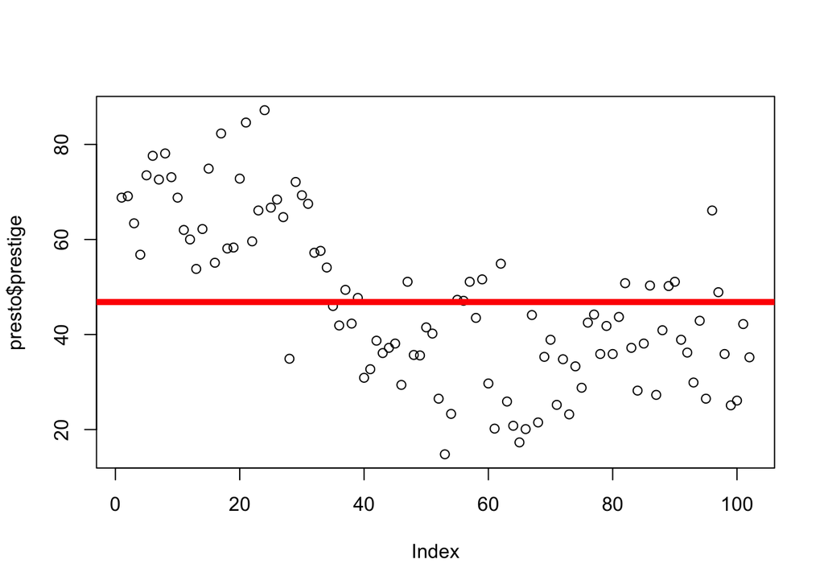

```r
plot(presto$prestige)
abline(h = mean(presto$prestige), lwd = 5, col = 'red')
```

The mean was a good starting place to make predictions for two reasons :

1. By definition, the mean is the value that is closest to all the scores. In other words, the mean minimizes the error in our predictions.
   - *NOTE:* Eagle eyed students may note something odd about the way the data are arranged on this graph - it looks like there’s some quadratic (curved) pattern in the way the data are arranged. Because the x-axis for this graph (the index) is the row in which each data, all this quadratic pattern means is that more presitgious jobs tended to be listed earlier in the dataset than less prestigious jobs.
2. The mean is static (it does not change), meaning we can make the same prediction for every person. This is a good place to start, but obviously there’s a lot of error in our predictions. In fact, using our knowledge of residual errors, we can calculate this total (squared) error when we use the mean to make a prediction

```r
residual <- presto$prestige - mean(presto$prestige)
sum(residual^2)
```

```
## [1] 29895.43
```

This value is the sum of the squared residuals (also called the **sum of the squared errors** or often abbreviated **SSE**), and is an important statistic that we will come back to at the end of this lecture!

So, to recap : we are interested in a varible (prestige), we can make *pretty good* predictions about prestige based on the mean (since by definition the mean is closest to all the scores in the data), and we are able to quantify how good our prediction is by calculating the sum of square errors.

In the next section, we’ll try to improve upon our predictions of prestige.

#### The Linear Model

The **linear model** is a simple, yet flexible, way to make predictions about one variable (the DV or $y$). There are many types of models, but most follow the same basic principles that we will review in this document. (The mean is actually a linear model in its simplest form.)

The mean is a great starting place, but its limited because it’s static - we have the same prediction for everyone in the dataset, when we know that people differ. So we will want to come up with predictions that change, depending on what we learn about another person. This is something I refer to as **the principle of covariation**. It’s a simple idea - if there’s a pattern in how two things vary, then we can use information about one variable to make a prediction about what will happen for the other variable. This is what we talked about earlier in the semester when we discussed the idea of prediction - we’re just formalizing this idea with numbers now.

So, as a conceptual example, there is variation in $rain$ (somedays it rains and somedays it does not) and there is variation in $clouds$ (bright skies some days; clouds other days).

The *covariation* happens as I notice that on days when it rains (variable = $rain$), it also tends to be cloudy (variable = $clouds$). These two variables vary together (they “co-vary”). Of course, this pattern isn’t always true - there’s $error$.

I could write this as a model, where my predictions about whether it will rain will be influenced by whether I see clouds in the sky :

$$rain = clouds + error$$

Of course, I could define another model, let’s say based on the pattern of covariation I notice that on days when it’s raining, I tend to hear raindrops (and on days when it’s not raining, I don’t tend to hear raindrops.)

$$rain = rain sounds + error$$

These models look similar, but are not equal. If I had to guess, I’d say that hearing rain is a *better* way to make predictions of rain than looking at the clouds. So not only do models use information about which variables you can use to make predictions about another, but they also tell you how much you should update your predictions about one variable from another.

This conceptual equation of $actual.score = our.prediction + error$ can be written using mathematical notation:

$$y_i = a + b_{1}X_{i} + \varepsilon_{i}$$

- $y_{i}$ = the individual’s **actual score** that we are trying to predict (the $_i$ symbol represents that each individual will have a specific y value)
- $a$ = **the intercept** = the starting place for our prediction. You should think of the intercept as “the predicted value of y when all x values are zero”.)
- $X_i$ = the individual’s specific value of x. Again, the $_i$ next to the $X$ describes the idea that each individual has a specific value of X. (If X was height, then this would be the individual’s specific height.)
- $b_1$ = **the slope** = the adjustment we make in our prediction of y, based on the individual’s x value. The slope tells us how x and y are related:
  - a zero for the slope means that there is no relationship
  - a positive number for the slope means that as x increases, y also increases (and as x decreases in value, y also decreases)
  - a negative number for the slope means that as x increases, y decreases (or as x decreases, y increases)
- $\varepsilon_i$ = residual error = the distance between the predicted values of y and the individual’s actual value of y

In sum, a model is just a line that to update our predictions of Y, based on information in X. I think this will make a lot more sense if we work through an example or two.

#### Example #1

For this first example, let’s predict the variable `prestige` from the variable `education` - another continuous variable in the Prestige dataset.

Let’s graph these two variables side by side.

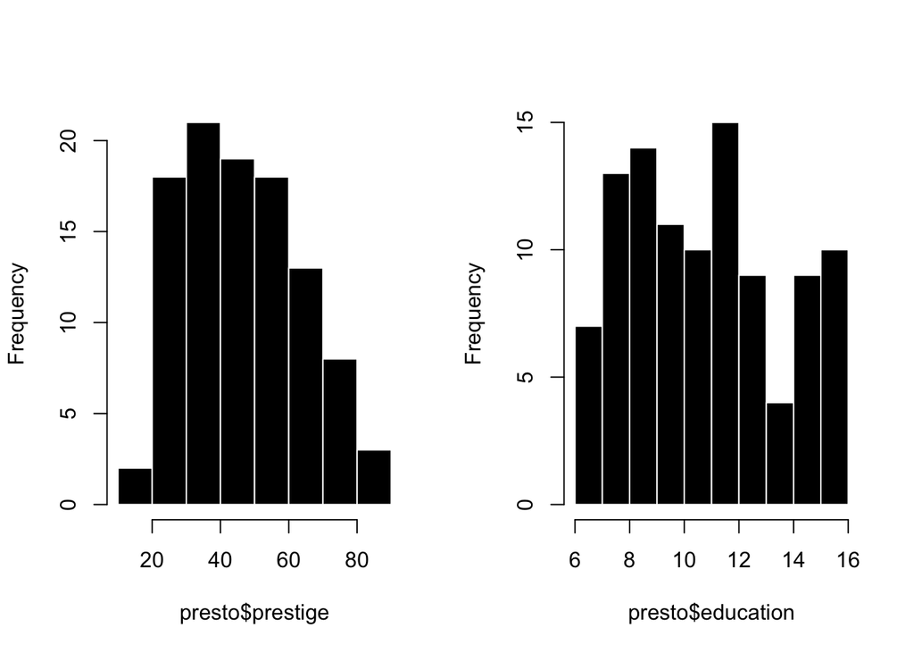

```r
par(mfrow = c(1,2)) # splits my graphing window
hist(presto$prestige, col = 'black', bor = 'white', main = "")
hist(presto$education, col = 'black', bor = 'white', main = "")
```

Great. So both prestige and education vary. Not every job has the same prestige, and not every job requires the same years of education.

The question is whether these two variables **covary**. I’m guessing that some of you are thinking that because both distributions are slighly positively skewed, this means that there is some covariation between these variables. However, this is an example of *patterns in randomness* - we can’t really tell whether there is covariation from these two separate graphs.

In order to examine the covariation, we need to use a **scatterplot**. A scatterplot graphs individual scores in terms of one variable on the Y axis (the veritcal line) and the other variable on the X axis (the horizontal line).

To graph a scatterplot, you can use the `plot()` function, and tell R to predict one variable (in this case prestige) from another (eduacation).

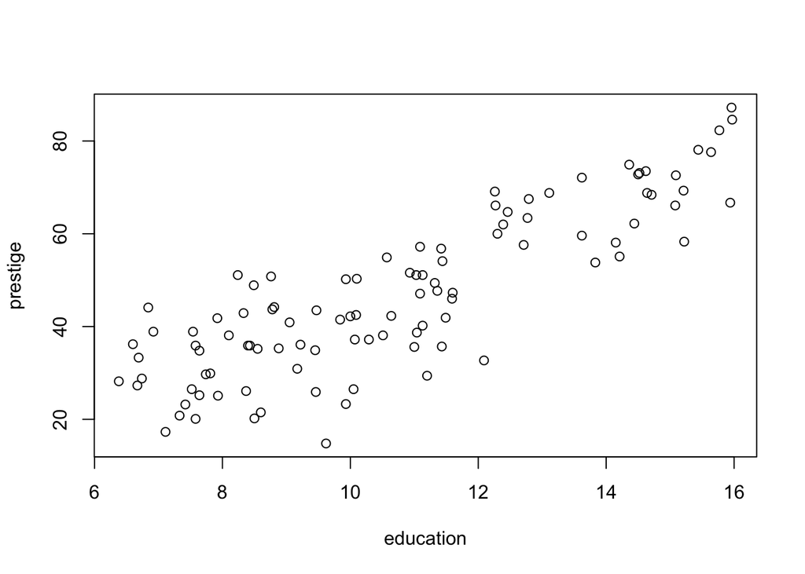

```r
plot(prestige ~ education, data = presto)
```

> WATCH THIS VIDEO : for an explanation of what’s going on in the graph above.

To define the model, we just need to use a few lines of code.

```r
mod <- lm(prestige ~ education, data = presto) # this defines the model, and then saves it to an object (called mod)
coef(mod) # this shows me the values of the model
```

```
## (Intercept)   education
##  -10.731982    5.360878
```

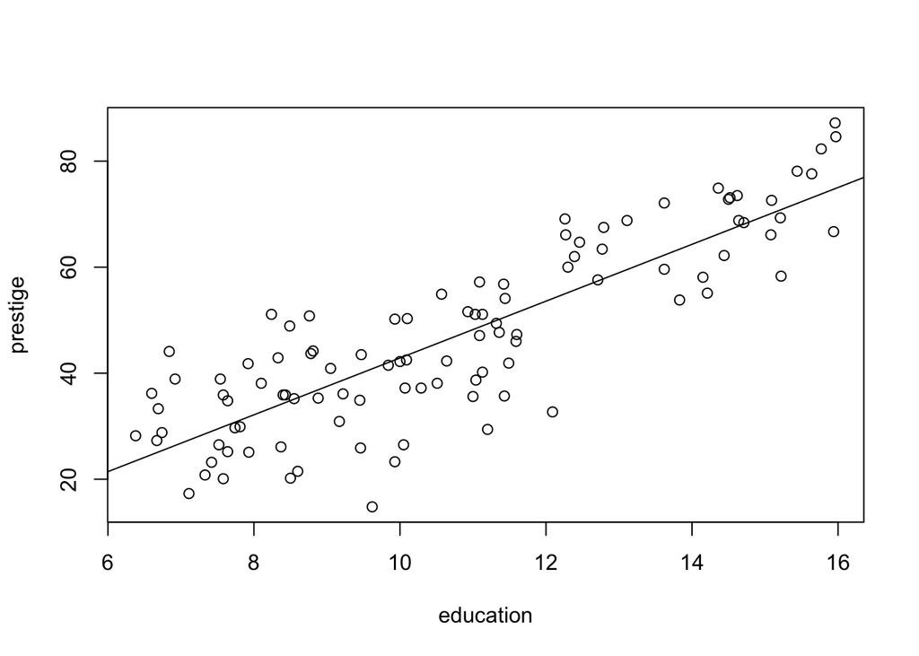

```r
plot(prestige ~ education, data = presto) # plots the model again
abline(mod) # this adds the line to my graph.
```

#### R<sup>2</sup>

Okay, final part of the lab. Promise we are almost done. And this will be fast.

Remember our goal is to make good predictions that have little error. So to evaluate the quality of our predictions, we need to evaluate how much error there is. We already learned how to do this when the mean was being used to make predictions - the only difference is that with a more complex model, we have more complex predictions (not just the static mean.)

Fortunately, R does the hard work of making predictions for us, and even saves the **residual errors** as part of the model output.

For example, from our model where we predicted prestige from education:

```r
mod$residuals # these are the residuals (the errors from our model)
```

```
##        gov.administrators          general.managers
##                9.25087492               14.10762099
##               accountants       purchasing.officers
##                5.67357335                6.31075828
##                  chemists                physicists
##                5.85594955                4.48785426
##                biologists                architects
##                2.43633701                6.06002981
##           civil.engineers          mining.engineers
##                5.99203732                1.04873199
##                 surveyors               draughtsmen
##                6.31070689                4.79318588
##       computer.programers                economists
##               -9.60895705               -4.47909246
##             psychologists            social.workers
##                8.64977776              -10.34609058
##                   lawyers                librarians
##                8.49094016               -7.02443792
##    vocational.counsellors                 ministers
##              -12.56057709                5.79925487
##       university.teachers   primary.school.teachers
##                9.71876461               -2.68317272
## secondary.school.teachers                physicians
##               -4.01005421               12.37237339
##             veterinarians  osteopaths.chiropractors
##               -8.02040906                0.27347055
##                    nurses             nursing.aides
##                8.63544545               -5.02831259
##          physio.therapsts               pharmacists
##                9.81682728               -1.50696831
##       medical.technicians        commercial.artists
##                9.66635579                8.47984794
##       radio.tv.announcers                  athletes
##                0.19522601                3.50354073
##               secretaries                   typists
##               -5.40059093               -8.96450316
##               bookkeepers          tellers.cashiers
##               -0.55315394               -4.00775709
##        computer.operators           shipping.clerks
##               -2.46758905               -7.52726682
```

[output cut: 47 more lines]

```
##                2.27492751                3.11603851
##              electricians      construction.foremen
##                7.69846610               17.65834947
##                carpenters                    masons
##               12.53470807               11.55018895
##            house.painters                  plumbers
##               -1.23647311                8.97587047
##    construction.labourers                    pilots
##               -3.08181857               11.05401221
##           train.engineers               bus.drivers
##               14.11813004                5.99652877
##              taxi.drivers              longshoremen
##               -6.67977844               -8.03856464
##               typesetters               bookbinders
##               -0.67679534                0.09647737
```

```r
mod$residuals^2 # these are the squared residuals
```

```
##        gov.administrators          general.managers
##              8.557869e+01              1.990250e+02
##               accountants       purchasing.officers
##              3.218943e+01              3.982567e+01
##                  chemists                physicists
##              3.429215e+01              2.014084e+01
##                biologists                architects
##              5.935738e+00              3.672396e+01
##           civil.engineers          mining.engineers
##              3.590451e+01              1.099839e+00
##                 surveyors               draughtsmen
##              3.982502e+01              2.297463e+01
##       computer.programers                economists
##              9.233206e+01              2.006227e+01
##             psychologists            social.workers
##              7.481866e+01              1.070416e+02
##                   lawyers                librarians
##              7.209606e+01              4.934273e+01
##    vocational.counsellors                 ministers
##              1.577681e+02              3.363136e+01
##       university.teachers   primary.school.teachers
##              9.445439e+01              7.199416e+00
## secondary.school.teachers                physicians
##              1.608053e+01              1.530756e+02
##             veterinarians  osteopaths.chiropractors
##              6.432696e+01              7.478614e-02
##                    nurses             nursing.aides
##              7.457092e+01              2.528393e+01
##          physio.therapsts               pharmacists
##              9.637010e+01              2.270953e+00
##       medical.technicians        commercial.artists
##              9.343843e+01              7.190782e+01
##       radio.tv.announcers                  athletes
##              3.811320e-02              1.227480e+01
##               secretaries                   typists
##              2.916638e+01              8.036232e+01
##               bookkeepers          tellers.cashiers
##              3.059793e-01              1.606212e+01
##        computer.operators           shipping.clerks
##              6.088996e+00              5.665975e+01
```

[output cut: 47 more lines]

```
##              5.175295e+00              9.709696e+00
##              electricians      construction.foremen
##              5.926638e+01              3.118173e+02
##                carpenters                    masons
##              1.571189e+02              1.334069e+02
##            house.painters                  plumbers
##              1.528866e+00              8.056625e+01
##    construction.labourers                    pilots
##              9.497606e+00              1.221912e+02
##           train.engineers               bus.drivers
##              1.993216e+02              3.595836e+01
##              taxi.drivers              longshoremen
##              4.461944e+01              6.461852e+01
##               typesetters               bookbinders
##              4.580519e-01              9.307883e-03
```

```r
sum(mod$residuals^2) # these are the sum of the squared residuals
```

```
## [1] 8286.99
```

Notice that the sum of the squared errors for this model, where we use education to predict prestige, is less than the sum of the squared errors from the model where we used the mean to make predictons.

In fact, we can calculate exactly how large this differences in errors is between the two predictions.

```r
sum(residual^2) - sum(mod$residuals^2)
```

```
## [1] 21608.44
```

This tells me that the model where we use education to predict prestige reduces the squared error by 21608.44. That is a large number! But it’s hard to understand how large it is, because it’s missing context.

To provide this number context, we can describe how large this reduction in residual error is, relative to the original residual error that we had when we used the mean to make predictions.

```r
(sum(residual^2) - sum(mod$residuals^2)) / sum(residual^2)
```

```
## [1] 0.7228007
```

This statistic is called **R<sup>2</sup> (“r-squared”)**, and is defined by the following equation:
$$R^{2} = \frac{SS_{mean} - SS_{model}}{SS_{mean}}$$
What R<sup>2</sup> does is contextualizes our reduction in error, by describing how much less error we have in our model, compared to the error that we had when using just the mean to make predictions. + Another way to think of R<sup>2</sup> is that it describes the percentage of variation in the DV that our model is able to predict or explain. + R<sup>2</sup> can range from 0 to 1. The closer to zero, the less our model improves upon predictions (because 0 = no difference between the error when using the mean to make predictions and the error when using the model to make predictions). The closer to one, the more our model improves upon predictions. An R<sup>2</sup> of 1 would mean that you are making perfect predictions. If this happens, you have probably done something wrong. Or will win a Nobel prize and / or have a fantastic career in advertising.